# Employed

# 1 Description of DataSchema variable

The description of harmonised variable is the following:

- Short name: `employed`
- Variable label: `Participant has currently paid employement`
- Variable description: `Paid employment pertains to currently doing full- or part-time paid work (not including volunteering, housework or providing care (unless paid)). Respondents may be retired, while still undertaking some form of paid work`
- Domain: `Socio-demographic and economic characteristics`
- Value type: `categorical`
- Category coding:

| **Code** | **Category Label** |
| --- | --- |
| 0 | No |
| 1 | Yes |

- Category missings:

| **Code** | **Category Label** |
| --- | --- |
| 991 | CAPI/interviewer error |
| 992 | Impute |
| 993 | Disable to measure |
| 994 | Not attempt/not done |
| 995 | Does not answer |
| 996 | Not applicable |
| 997 | Refuse |
| 998 | Do not know |
| 999 | Missing |

# 2 Data process

## 2.1 England

### 2.1.1 Wave 1

#### 2.1.1.1 Study-specific variable description

| **Name** | `wpdes` |
| --- | --- |
| **Label** | `Which one of these would you say best describes your current situation?` |
| **Table name** | `wave_1_core_data_v3` |
| **Categories** | `1 = Retired` `2 = Employed` `3 = Self-employed` `4 = Unemployed` `5 = Permanently sick or disabled` `6 = Looking after home or family` `85 = Other answer - not codeable 01 to 06 or 96` `86 = Irreleva… |
| **Missings** | `-1 = Not applicable` `-8 = Don't Know` `-9 = Refusal` |
| **Description** |  |

wpdes

| Sample size | Missing values |
| --- | --- |
| 12099 | 10 |

Category

|  | 1 | 2 | 3 | 4 | 5 | 6 | 85 | 96 |
| --- | --- | --- | --- | --- | --- | --- | --- | --- |
| Frequency | 5715.00 | 3427.00 | 696.00 | 126.00 | 790.00 | 1202.00 | 55.00 | 78.00 |
| Percentage | 47.24 | 28.32 | 5.75 | 1.04 | 6.53 | 9.93 | 0.45 | 0.64 |

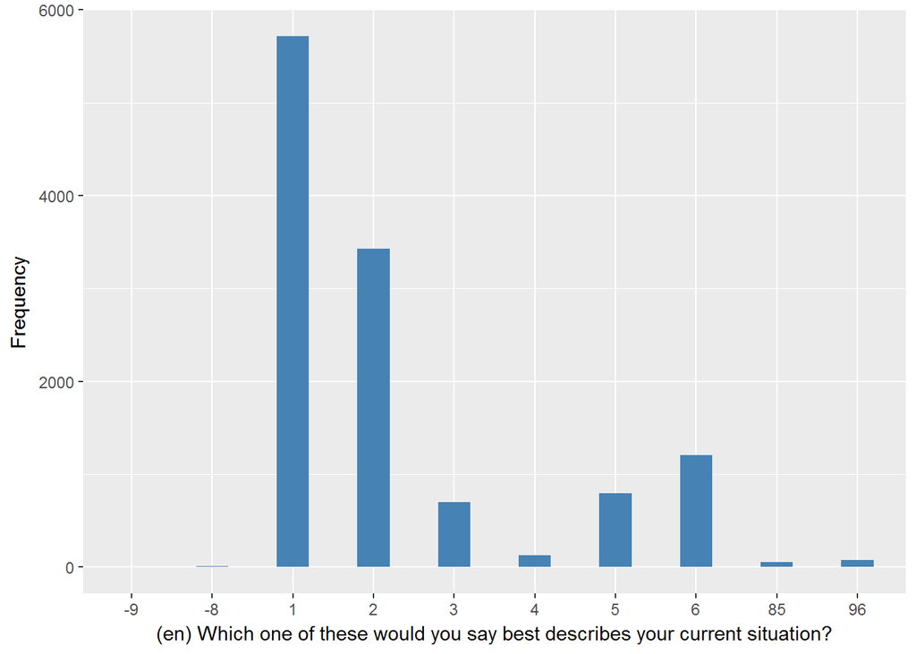

#### 2.1.1.2 Harmonisation algorithm

To compute `employed` from the study-specific variable it has to be recoded as follows:

- `2,3 into 1`
- `1,4,5,6,96 into 0`
- `85,86,95 into 999`
- `-1 into 996`
- `-8 into 998`
- `-9 into 997`

**R script:**

```r
ELSA_ds_w1 <- tibble(id = ELSA_w1$id)
ELSA_ds_w1$employed <- car::recode(ELSA_w1$wpdes, "c(2,3) = 1; c(1,4,5,6,96) = 0; c(85,86,95) = 999; -1 = 996; -8 = 998; -9 = 997")
```

#### 2.1.1.3 Statistics of the new harmonized variable

Participant has currently paid employement

| Sample size | Missing values |
| --- | --- |
| 12099 | 65 |

Category

|  | 0 | 1 |
| --- | --- | --- |
| Frequency | 7911.00 | 4123.00 |
| Percentage | 65.39 | 34.08 |

Type of missing

|  | 991 | 992 | 993 | 994 | 995 | 996 | 997 | 998 | 999 | NA |
| --- | --- | --- | --- | --- | --- | --- | --- | --- | --- | --- |
| Frequency | 0 | 0 | 0 | 0 | 0 | 0 | 4.00 | 6.00 | 55.00 | 0 |
| Percentage | 0 | 0 | 0 | 0 | 0 | 0 | 0.03 | 0.05 | 0.45 | 0 |

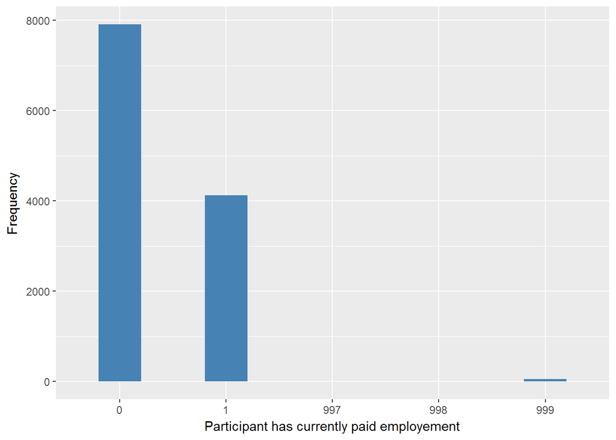

#### 2.1.1.4 Validation

|  | 1,4,5,6,96->0 | 2,3->1 | -9->997 | -8->998 | 85,86,95->999 |
| --- | --- | --- | --- | --- | --- |
| BeforeH | 7911 | 4123 | 4 | 6 | 55 |
| AfterH | 7911 | 4123 | 4 | 6 | 55 |

### 2.1.2 Wave 2

#### 2.1.2.1 Study-specific variable description

| **Name** | `wpdes` |
| --- | --- |
| **Label** | `Best description of current situation` |
| **Table name** | `wave_2_core_data_v4` |
| **Categories** | `1 = Retired` `2 = Employed` `3 = Self-employed` `4 = Unemployed` `5 = Permanently sick or disabled` `6 = Looking after home or family` `85 = Other answer - not codeable 01 to 06 or 96` `86 = Irreleva… |
| **Missings** | `-1 = Not applicable` `-8 = Don't Know` `-9 = Refusal` |
| **Description** |  |

wpdes

| Sample size | Missing values |
| --- | --- |
| 9432 | 2 |

Category

|  | 1 | 2 | 3 | 4 | 5 | 6 | 85 | 96 |
| --- | --- | --- | --- | --- | --- | --- | --- | --- |
| Frequency | 4775.00 | 2452 | 524.00 | 75.0 | 539.00 | 986.00 | 30.00 | 49.00 |
| Percentage | 50.63 | 26 | 5.56 | 0.8 | 5.71 | 10.45 | 0.32 | 0.52 |

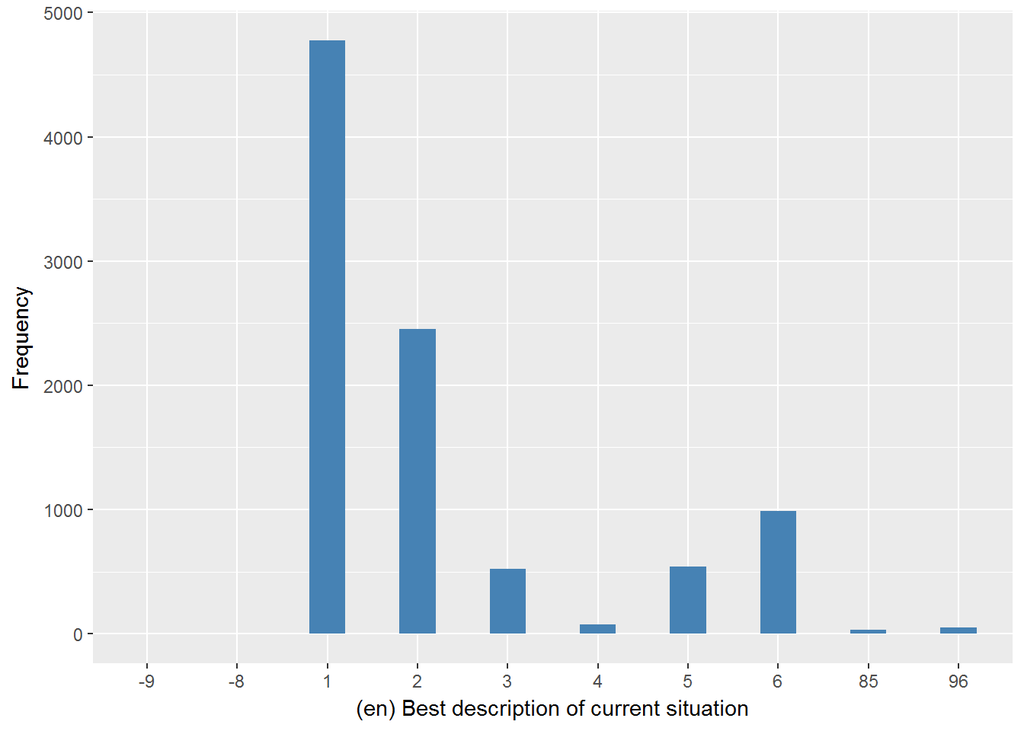

#### 2.1.2.2 Harmonisation algorithm

To compute `employed` from the study-specific variable it has to be recoded as follows:

- `2,3 into 1`
- `1,4,5,6,96 into 0`
- `85,86,95 into 999`
- `-1 into 996`
- `-8 into 998`
- `-9 into 997`

**R script:**

```r
ELSA_ds_w2 <- tibble(id = ELSA_w2$id)
ELSA_ds_w2$employed <- car::recode(ELSA_w2$wpdes, "c(2,3) = 1; c(1,4,5,6,96) = 0; c(85,86,95) = 999; -1 = 996; -8 = 998; -9 = 997")
```

#### 2.1.2.3 Statistics of the new harmonized variable

Participant has currently paid employement

| Sample size | Missing values |
| --- | --- |
| 9432 | 32 |

Category

|  | 0 | 1 |
| --- | --- | --- |
| Frequency | 6424.00 | 2976.00 |
| Percentage | 68.11 | 31.55 |

Type of missing

|  | 991 | 992 | 993 | 994 | 995 | 996 | 997 | 998 | 999 | NA |
| --- | --- | --- | --- | --- | --- | --- | --- | --- | --- | --- |
| Frequency | 0 | 0 | 0 | 0 | 0 | 0 | 1.00 | 1.00 | 30.00 | 0 |
| Percentage | 0 | 0 | 0 | 0 | 0 | 0 | 0.01 | 0.01 | 0.32 | 0 |

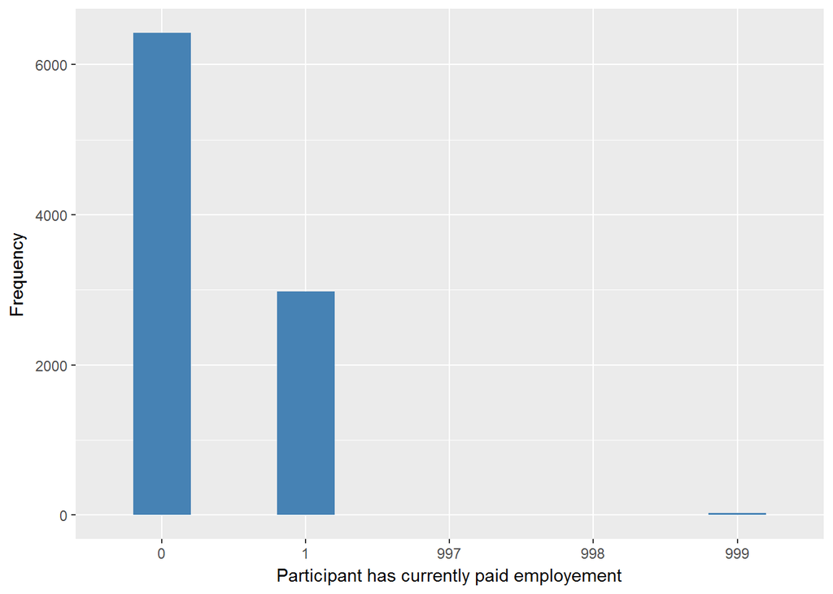

#### 2.1.2.4 Validation

|  | 1,4,5,6,96->0 | 2,3->1 | -9->997 | -8->998 | 85,86,95->999 |
| --- | --- | --- | --- | --- | --- |
| BeforeH | 6424 | 2976 | 1 | 1 | 30 |
| AfterH | 6424 | 2976 | 1 | 1 | 30 |

### 2.1.3 Wave 3

#### 2.1.3.1 Study-specific variable description

| **Name** | `wpdes` |
| --- | --- |
| **Label** | `Best description of current situation` |
| **Table name** | `wave_3_elsa_data_v4` |
| **Categories** | `1 = Retired` `2 = Employed` `3 = Self-employed` `4 = Unemployed` `5 = Permanently sick or disabled` `6 = Looking after home or family` `95 = Other (SPECIFY)` `96 = SPONTANEOUS : Semi-retired` |
| **Missings** | `-1 = Not applicable` `-8 = Don't Know` `-9 = Refusal` |
| **Description** |  |

wpdes

| Sample size | Missing values |
| --- | --- |
| 9771 | 4 |

Category

|  | 1 | 2 | 3 | 4 | 5 | 6 | 95 | 96 |
| --- | --- | --- | --- | --- | --- | --- | --- | --- |
| Frequency | 4580.00 | 3065.00 | 623.00 | 85.00 | 539.00 | 816.00 | 22.00 | 37.00 |
| Percentage | 46.87 | 31.37 | 6.38 | 0.87 | 5.52 | 8.35 | 0.23 | 0.38 |

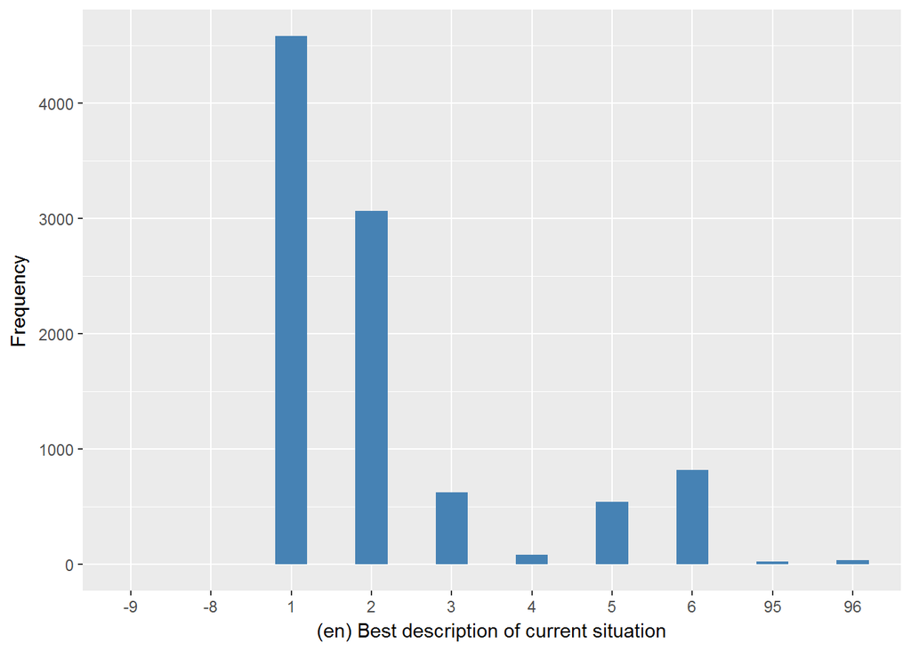

#### 2.1.3.2 Harmonisation algorithm

To compute `employed` from the study-specific variable it has to be recoded as follows:

- `2,3 into 1`
- `1,4,5,6,96 into 0`
- `95 into 999`
- `-1 into 996`
- `-8 into 998`
- `-9 into 997`

**R script:**

```r
ELSA_ds_w3 <- tibble(id = ELSA_w3$id)
ELSA_ds_w3$employed <- car::recode(ELSA_w3$wpdes, "c(2,3) = 1; c(1,4,5,6,96) = 0; c(95) = 999; -1 = 996; -8 = 998; -9 = 997")
```

#### 2.1.3.3 Statistics of the new harmonized variable

Participant has currently paid employement

| Sample size | Missing values |
| --- | --- |
| 9771 | 26 |

Category

|  | 0 | 1 |
| --- | --- | --- |
| Frequency | 6057.00 | 3688.00 |
| Percentage | 61.99 | 37.74 |

Type of missing

|  | 991 | 992 | 993 | 994 | 995 | 996 | 997 | 998 | 999 | NA |
| --- | --- | --- | --- | --- | --- | --- | --- | --- | --- | --- |
| Frequency | 0 | 0 | 0 | 0 | 0 | 0 | 2.00 | 2.00 | 22.00 | 0 |
| Percentage | 0 | 0 | 0 | 0 | 0 | 0 | 0.02 | 0.02 | 0.23 | 0 |

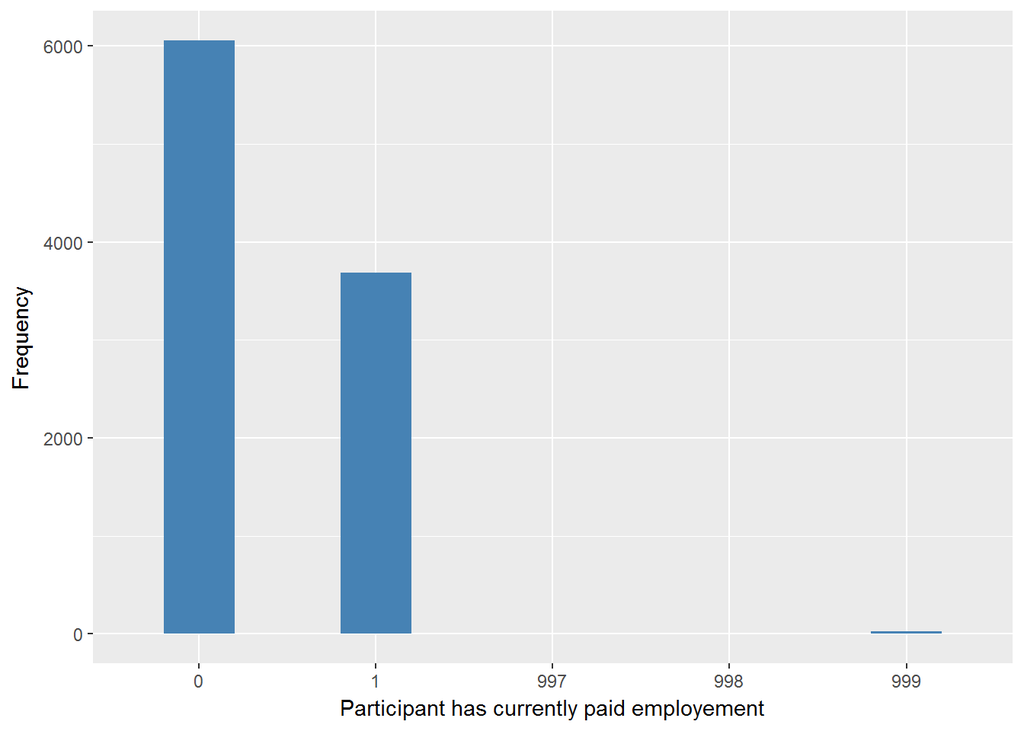

#### 2.1.3.4 Validation

|  | 1,4,5,6,96->0 | 2,3->1 | -9->997 | -8->998 | 95->999 |
| --- | --- | --- | --- | --- | --- |
| BeforeH | 6057 | 3688 | 2 | 2 | 22 |
| AfterH | 6057 | 3688 | 2 | 2 | 22 |

### 2.1.4 Wave 4

#### 2.1.4.1 Study-specific variable description

| **Name** | `wpdes` |
| --- | --- |
| **Label** | `Best description of current situation` |
| **Table name** | `wave_4_elsa_data_v3` |
| **Categories** | `1 = Retired` `2 = Employed` `3 = Self-employed` `4 = Unemployed` `5 = Permanently sick or disabled` `6 = Looking after home or family` `85 = Other answer - not codeable` `86 = Code86` `95 = Other` `9… |
| **Missings** | `-1 = Not applicable` `-2 = CAPI/Interview error` `-8 = Don't Know` `-9 = Refusal` |
| **Description** |  |

wpdes

| Sample size | Missing values |
| --- | --- |
| 11050 | 12 |

Category

|  | 1 | 2 | 3 | 4 | 5 | 6 | 85 | 95 | 96 |
| --- | --- | --- | --- | --- | --- | --- | --- | --- | --- |
| Frequency | 5543.00 | 3253.00 | 733.00 | 132.00 | 592.00 | 722.00 | 1.00 | 1.00 | 61.00 |
| Percentage | 50.16 | 29.44 | 6.63 | 1.19 | 5.36 | 6.53 | 0.01 | 0.01 | 0.55 |

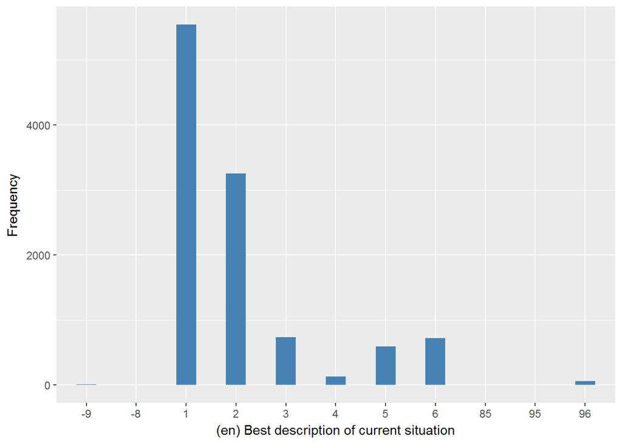

#### 2.1.4.2 Harmonisation algorithm

To compute `employed` from the study-specific variable it has to be recoded as follows:

- `2,3 into 1`
- `1,4,5,6,96 into 0`
- `85,86,95 into 999`
- `-1 into 996`
- `-2 into 991`
- `-8 into 998`
- `-9 into 997`

**R script:**

```r
ELSA_ds_w4 <- tibble(id = ELSA_w4$id)
ELSA_ds_w4$employed <- car::recode(ELSA_w4$wpdes, "c(2,3) = 1; c(1,4,5,6,96) = 0; c(85,86,95) = 999; -1 = 996; -2 = 991; -8 = 998; -9 = 997")
```

#### 2.1.4.3 Statistics of the new harmonized variable

Participant has currently paid employement

| Sample size | Missing values |
| --- | --- |
| 11050 | 14 |

Category

|  | 0 | 1 |
| --- | --- | --- |
| Frequency | 7050.0 | 3986.00 |
| Percentage | 63.8 | 36.07 |

Type of missing

|  | 991 | 992 | 993 | 994 | 995 | 996 | 997 | 998 | 999 | NA |
| --- | --- | --- | --- | --- | --- | --- | --- | --- | --- | --- |
| Frequency | 0 | 0 | 0 | 0 | 0 | 0 | 8.00 | 4.00 | 2.00 | 0 |
| Percentage | 0 | 0 | 0 | 0 | 0 | 0 | 0.07 | 0.04 | 0.02 | 0 |

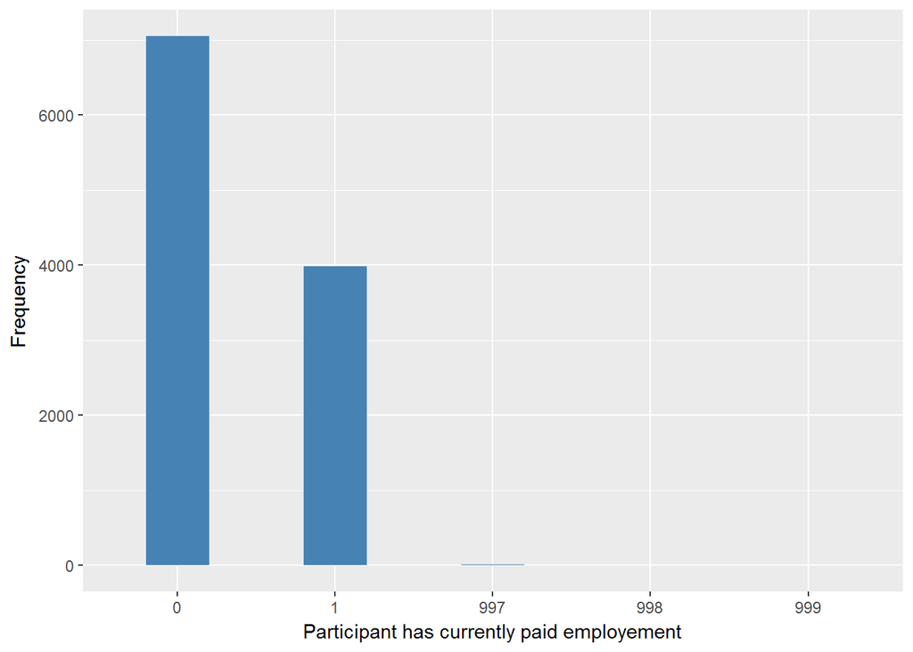

#### 2.1.4.4 Validation

|  | 1,4,5,6,96->0 | 2,3->1 | -9->997 | -8->998 | 85,86,95->999 |
| --- | --- | --- | --- | --- | --- |
| BeforeH | 7050 | 3986 | 8 | 4 | 2 |
| AfterH | 7050 | 3986 | 8 | 4 | 2 |

### 2.1.5 Wave 5

#### 2.1.5.1 Study-specific variable description

| **Name** | `wpdes` |
| --- | --- |
| **Label** | `Best description of current situation` |
| **Table name** | `wave_5_elsa_data_v4` |
| **Categories** | `1 = Retired` `2 = Employed` `3 = Self-employed` `4 = Unemployed` `5 = Permanently sick or disabled` `6 = Looking after home or family` `85 = Other answer` `86 = Irrelevant response` `95 = Other (SPEC… |
| **Missings** | `-1 = Not applicable` `-2 = Schedule not applicable` `-8 = Don't Know` `-9 = Refusal` |
| **Description** |  |

wpdes

| Sample size | Missing values |
| --- | --- |
| 10274 | 8 |

Category

|  | 1 | 2 | 3 | 4 | 5 | 6 | 85 | 86 | 96 |
| --- | --- | --- | --- | --- | --- | --- | --- | --- | --- |
| Frequency | 5676.00 | 2613.00 | 646.00 | 114.00 | 515.00 | 612.00 | 31.0 | 2.00 | 57.00 |
| Percentage | 55.25 | 25.43 | 6.29 | 1.11 | 5.01 | 5.96 | 0.3 | 0.02 | 0.55 |

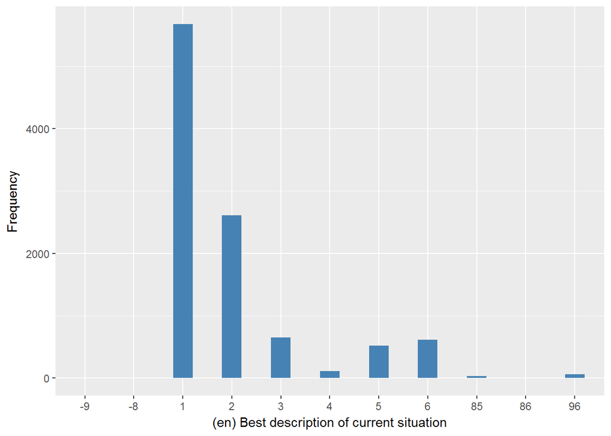

#### 2.1.5.2 Harmonisation algorithm

To compute `employed` from the study-specific variable it has to be recoded as follows:

- `2,3 into 1`
- `1,4,5,6,96 into 0`
- `85,86,95 into 999`
- `-1 into 996`
- `-2 into 996`
- `-8 into 998`
- `-9 into 997`

**R script:**

```r
ELSA_ds_w5 <- tibble(id = ELSA_w5$id)
ELSA_ds_w5$employed <- car::recode(ELSA_w5$wpdes, "c(2,3) = 1; c(1,4,5,6,96) = 0; c(85,86,95) = 999; -1 = 996; -2 = 996; -8 = 998; -9 = 997")
```

#### 2.1.5.3 Statistics of the new harmonized variable

Participant has currently paid employement

| Sample size | Missing values |
| --- | --- |
| 10274 | 41 |

Category

|  | 0 | 1 |
| --- | --- | --- |
| Frequency | 6974.00 | 3259.00 |
| Percentage | 67.88 | 31.72 |

Type of missing

|  | 991 | 992 | 993 | 994 | 995 | 996 | 997 | 998 | 999 | NA |
| --- | --- | --- | --- | --- | --- | --- | --- | --- | --- | --- |
| Frequency | 0 | 0 | 0 | 0 | 0 | 0 | 4.00 | 4.00 | 33.00 | 0 |
| Percentage | 0 | 0 | 0 | 0 | 0 | 0 | 0.04 | 0.04 | 0.32 | 0 |

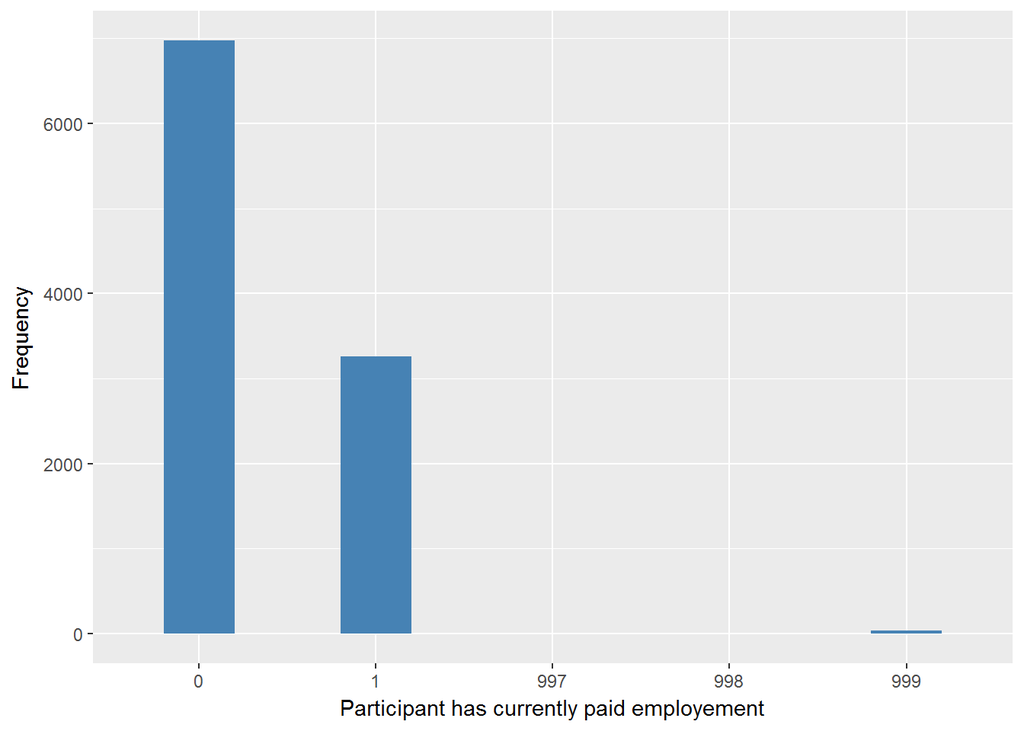

#### 2.1.5.4 Validation

|  | 1,4,5,6,96->0 | 2,3->1 | -9->997 | -8->998 | 85,86,95->999 |
| --- | --- | --- | --- | --- | --- |
| BeforeH | 6974 | 3259 | 4 | 4 | 33 |
| AfterH | 6974 | 3259 | 4 | 4 | 33 |

### 2.1.6 Wave 6

#### 2.1.6.1 Study-specific variable description

| **Name** | `WpDes` |
| --- | --- |
| **Label** | `Best description of current situation` |
| **Table name** | `wave_6_elsa_data_v2` |
| **Categories** | `1 = Retired` `2 = Employed` `3 = Self-employed` `4 = Unemployed` `5 = Permanently sick or disabled` `6 = Looking after home or family` `85 = Other answer` `86 = Irrelevant response` `95 = Other (SPEC… |
| **Missings** | `-1 = Not applicable` `-2 = Schedule not applicable` `-8 = Don't Know` `-9 = Refusal` |
| **Description** |  |

WpDes

| Sample size | Missing values |
| --- | --- |
| 10601 | 2 |

Category

|  | 1 | 2 | 3 | 4 | 5 | 6 | 85 | 96 |
| --- | --- | --- | --- | --- | --- | --- | --- | --- |
| Frequency | 5898.00 | 2766.00 | 688.00 | 119.00 | 497.00 | 541.0 | 45.00 | 45.00 |
| Percentage | 55.64 | 26.09 | 6.49 | 1.12 | 4.69 | 5.1 | 0.42 | 0.42 |

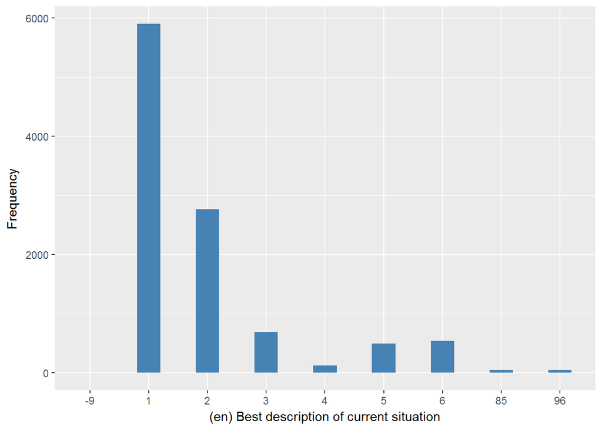

#### 2.1.6.2 Harmonisation algorithm

To compute `employed` from the study-specific variable it has to be recoded as follows:

- `2,3 into 1`
- `1,4,5,6,96 into 0`
- `85,86,95 into 999`
- `-1 into 996`
- `-2 into 996`
- `-8 into 998`
- `-9 into 997`

**R script:**

```r
ELSA_ds_w6 <- tibble(id = ELSA_w6$id)
ELSA_ds_w6$employed <- car::recode(ELSA_w6$WpDes, "c(2,3) = 1; c(1,4,5,6,96) = 0; c(85,86,95) = 999; -1 = 996; -2 = 996; -8 = 998; -9 = 997")
```

#### 2.1.6.3 Statistics of the new harmonized variable

Participant has currently paid employement

| Sample size | Missing values |
| --- | --- |
| 10601 | 47 |

Category

|  | 0 | 1 |
| --- | --- | --- |
| Frequency | 7100.00 | 3454.00 |
| Percentage | 66.97 | 32.58 |

Type of missing

|  | 991 | 992 | 993 | 994 | 995 | 996 | 997 | 998 | 999 | NA |
| --- | --- | --- | --- | --- | --- | --- | --- | --- | --- | --- |
| Frequency | 0 | 0 | 0 | 0 | 0 | 0 | 2.00 | 0 | 45.00 | 0 |
| Percentage | 0 | 0 | 0 | 0 | 0 | 0 | 0.02 | 0 | 0.42 | 0 |

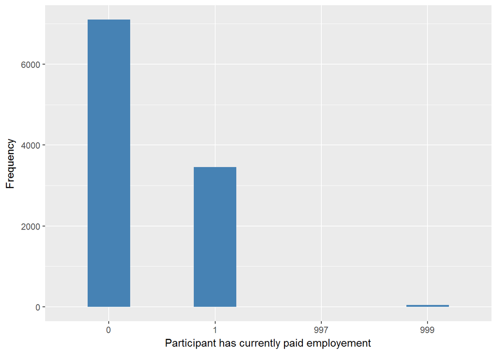

#### 2.1.6.4 Validation

|  | 1,4,5,6,96->0 | 2,3->1 | -9->997 | 85,86,95->999 |
| --- | --- | --- | --- | --- |
| BeforeH | 7100 | 3454 | 2 | 45 |
| AfterH | 7100 | 3454 | 2 | 45 |

### 2.1.7 Wave 7

| **Name** | `WpDes` |
| --- | --- |
| **Label** | `Best description of current situation` |
| **Table name** | `wave_7_elsa_data` |
| **Categories** | `1 = Retired` `2 = Employed` `3 = Self-employed` `4 = Unemployed` `5 = Permanently sick or disabled` `6 = Looking after home or family` `85 = Other answer` `86 = Irrelevant response` `95 = Other (SPEC… |
| **Missings** | `-1 = Not applicable` `-2 = Schedule not applicable` `-8 = Don't Know` `-9 = Refusal` |
| **Description** |  |

WpDes

| Sample size | Missing values |
| --- | --- |
| 9666 | 0 |

Category

|  | 1 | 2 | 3 | 4 | 5 | 6 | 85 | 86 | 96 |
| --- | --- | --- | --- | --- | --- | --- | --- | --- | --- |
| Frequency | 5624.00 | 2387.00 | 639.00 | 92.00 | 370.00 | 482.00 | 37.00 | 1.00 | 34.00 |
| Percentage | 58.18 | 24.69 | 6.61 | 0.95 | 3.83 | 4.99 | 0.38 | 0.01 | 0.35 |

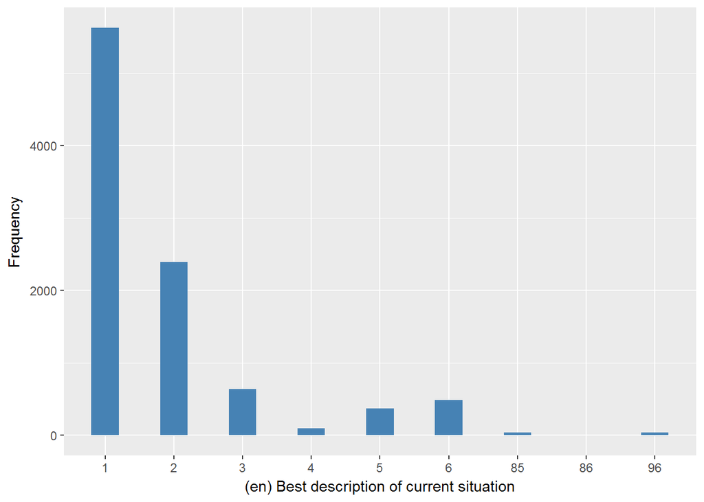

#### 2.1.7.1 Harmonisation algorithm

To compute `employed` from the study-specific variable it has to be recoded as follows:

- `2,3 into 1`
- `1,4,5,6,96 into 0`
- `85,86,95 into 999`
- `-1 into 996`
- `-2 into 996`
- `-8 into 998`
- `-9 into 997`

**R script:**

```r
ELSA_ds_w7 <- tibble(id = ELSA_w7$id)
ELSA_ds_w7$employed <- car::recode(ELSA_w7$WpDes, "c(2,3) = 1; c(1,4,5,6,96) = 0; c(85,86,95) = 999; -1 = 996; -2 = 996; -8 = 998; -9 = 997")
```

#### 2.1.7.2 Statistics of the new harmonized variable

Participant has currently paid employement

| Sample size | Missing values |
| --- | --- |
| 9666 | 38 |

Category

|  | 0 | 1 |
| --- | --- | --- |
| Frequency | 6602.0 | 3026.00 |
| Percentage | 68.3 | 31.31 |

Type of missing

|  | 991 | 992 | 993 | 994 | 995 | 996 | 997 | 998 | 999 | NA |
| --- | --- | --- | --- | --- | --- | --- | --- | --- | --- | --- |
| Frequency | 0 | 0 | 0 | 0 | 0 | 0 | 0 | 0 | 38.00 | 0 |
| Percentage | 0 | 0 | 0 | 0 | 0 | 0 | 0 | 0 | 0.39 | 0 |

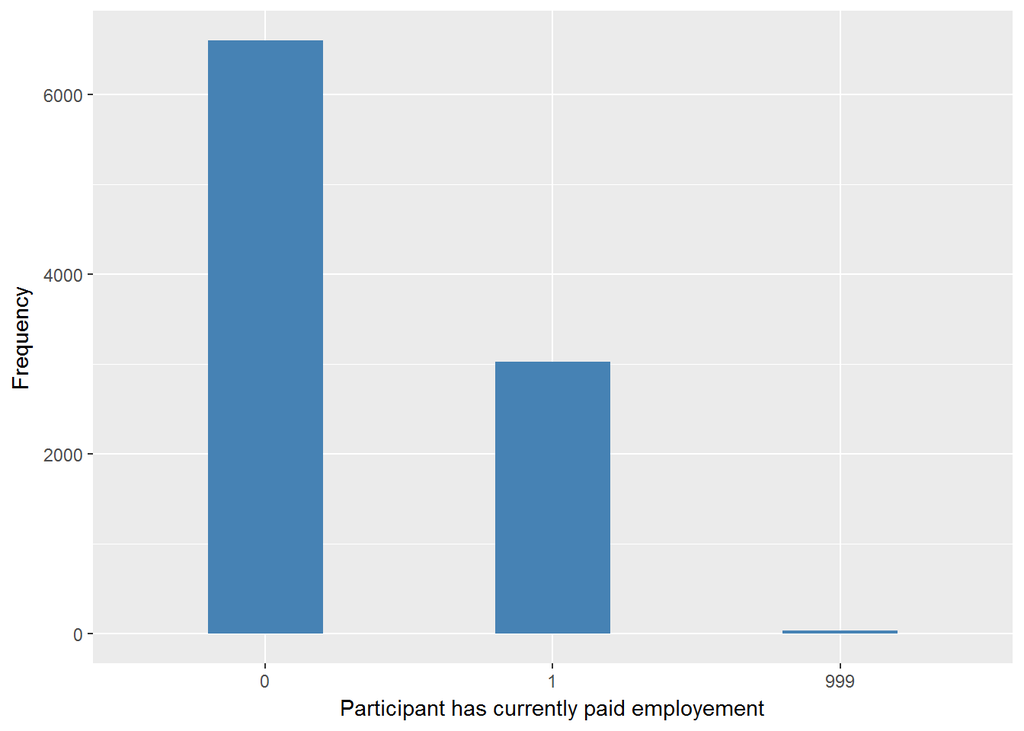

#### 2.1.7.3 Validation

|  | 1,4,5,6,96->0 | 2,3->1 | 85,86,95->999 |
| --- | --- | --- | --- |
| BeforeH | 6602 | 3026 | 38 |
| AfterH | 6602 | 3026 | 38 |

## 2.2 Summary of descriptive statistics of the harmonised variable accross populations and waves

Two tables are generated:

1. Percentages of categories in each harmonised variable.
2. Frequencies and percentages of individuals with different trajectories. To avoid too large table, Only trajectories with percentages larger than 0.3 are shown.

```r
l.hds <- list(w1 = ELSA_ds_w1, w2 = ELSA_ds_w2, w3 = ELSA_ds_w3, w4 = ELSA_ds_w4,
    w5 = ELSA_ds_w5, w6 = ELSA_ds_w6, w7 = ELSA_ds_w7)

for (name in names(l.hds)) {
    aux_object <- l.hds[[name]]
    label(l.hds[[name]][[2]]) <- label(aux_object[[2]]) <- ds_label  # Text value assigned at the DS description, at the top
    l.hds[[name]][[2]] <- labelled(l.hds[[name]][[2]], labels = cat_label)
    aux_object[[2]] <- car::recode(aux_object[[2]], "miss_values_vector=NA")
    aux_object[[2]] <- labelled(aux_object[[2]], labels = cat_label[1:2])
    m_name <- paste0("ELSA_m_ds_", name)
    assign(m_name, aux_object)
    rm(aux_object)
}

t.hds <- frq(l.hds[[1]][2])[[1]][, c(1, 2)]
for (i in seq_along(l.hds)) {
    t.hds[2 + i] <- frq(l.hds[[i]][2])[[1]][, 4]
}
t.hds[13, ] <- c("n", "sample size", sapply(l.hds, function(wave) length(wave[[1]])))
names(t.hds) <- c("val", "label", names(l.hds))
kable(t.hds)
```

| val | label | w1 | w2 | w3 | w4 | w5 | w6 | w7 |
| --- | --- | --- | --- | --- | --- | --- | --- | --- |
| 0 | No | 65.39 | 68.11 | 61.99 | 63.8 | 67.88 | 66.97 | 68.3 |
| 1 | Yes | 34.08 | 31.55 | 37.74 | 36.07 | 31.72 | 32.58 | 31.31 |
| 991 | CAPI interviewer error | 0 | 0 | 0 | 0 | 0 | 0 | 0 |
| 992 | Impute | 0 | 0 | 0 | 0 | 0 | 0 | 0 |
| 993 | Disable to measure | 0 | 0 | 0 | 0 | 0 | 0 | 0 |
| 994 | Not attempt not done | 0 | 0 | 0 | 0 | 0 | 0 | 0 |
| 995 | Does not answer | 0 | 0 | 0 | 0 | 0 | 0 | 0 |
| 996 | Not applicable | 0 | 0 | 0 | 0 | 0 | 0 | 0 |
| 997 | Refuse | 0.03 | 0.01 | 0.02 | 0.07 | 0.04 | 0.02 | 0 |
| 998 | Do not know | 0.05 | 0.01 | 0.02 | 0.04 | 0.04 | 0 | 0 |
| 999 | Missing | 0.45 | 0.32 | 0.23 | 0.02 | 0.32 | 0.42 | 0.39 |
| NA | NA | 0 | 0 | 0 | 0 | 0 | 0 | 0 |
| n | sample size | 12099 | 9432 | 9771 | 11050 | 10274 | 10601 | 9666 |

```r
dbb <- get(paste0("ELSA_m_ds_", names(l.hds)[1]))[, c("id", "employed")]
for (ind in 2:length(l.hds)) {
    dbb <- merge(dbb, get(paste0("ELSA_m_ds_", names(l.hds)[ind]))[, c("id",
        "employed")], by = "id", suffixes = c("", paste0(".", names(l.hds)[ind])),
        all = T)
}
names(dbb) <- c("id", names(l.hds))

v.dbb <- dbb[, 2]
for (ind in 2:length(l.hds)) {
    v.dbb <- paste0(v.dbb, dbb[, ind + 1])
}
f.dbb <- frq(v.dbb)[[1]][, c(1, 2, 4)]
kable(f.dbb[f.dbb[, 3] >= 0.3, ])
```

|  | val | frq | raw.prc |
| --- | --- | --- | --- |
| 1 | 0000000 | 2192 | 11.86 |
| 3 | 000000NA | 468 | 2.53 |
| 7 | 00000NANA | 382 | 2.07 |
| 15 | 0000NANANA | 487 | 2.63 |
| 25 | 000NA000 | 56 | 0.30 |
| 32 | 000NANANANA | 664 | 3.59 |
| 54 | 00NA0000 | 65 | 0.35 |
| 72 | 00NANANANANA | 898 | 4.86 |
| 141 | 0NA0NANANANA | 84 | 0.45 |
| 171 | 0NANANANANANA | 1534 | 8.30 |
| 172 | 1000000 | 267 | 1.44 |
| 241 | 10NANANANANA | 79 | 0.43 |
| 242 | 1100000 | 170 | 0.92 |
| 280 | 1110000 | 235 | 1.27 |
| 297 | 1111000 | 222 | 1.20 |
| 306 | 1111100 | 215 | 1.16 |
| 309 | 1111110 | 147 | 0.80 |
| 310 | 1111111 | 441 | 2.39 |
| 323 | 1111NANANA | 60 | 0.32 |
| 344 | 111NANANANA | 157 | 0.85 |
| 383 | 11NANANANANA | 280 | 1.51 |
| 466 | 1NANANANANANA | 538 | 2.91 |
| 513 | NANA00000 | 126 | 0.68 |
| 548 | NANA0NANANANA | 76 | 0.41 |
| 576 | NANA11110 | 64 | 0.35 |
| 577 | NANA11111 | 467 | 2.53 |
| 578 | NANA1111NA | 74 | 0.40 |
| 581 | NANA111NANA | 57 | 0.31 |
| 588 | NANA11NANANA | 80 | 0.43 |
| 607 | NANA1NANANANA | 234 | 1.27 |
| 608 | NANANA0000 | 832 | 4.50 |
| 610 | NANANA000NA | 154 | 0.83 |
| 616 | NANANA00NANA | 96 | 0.52 |
| 629 | NANANA0NANANA | 216 | 1.17 |
| 630 | NANANA1000 | 123 | 0.67 |
| 638 | NANANA1100 | 105 | 0.57 |
| 641 | NANANA1110 | 106 | 0.57 |
| 642 | NANANA1111 | 417 | 2.26 |
| 643 | NANANA111NA | 73 | 0.39 |
| 646 | NANANA11NANA | 68 | 0.37 |
| 654 | NANANA1NANANA | 147 | 0.80 |
| 671 | NANANANANA00 | 196 | 1.06 |
| 673 | NANANANANA0NA | 75 | 0.41 |
| 675 | NANANANANA11 | 665 | 3.60 |
| 676 | NANANANANA1NA | 190 | 1.03 |
| 677 | NANANANANANA0 | 117 | 0.63 |
| 678 | NANANANANANA1 | 393 | 2.13 |

# 3 Quality estimation

- We use the variables `wpdes` and not the variables `wpactw`, since the first ones describe formal employment, corresponding to the definition of the harmonized variable `employed`.